# mathanalysis_standardcalc201-208

```python
%%html
<style>
@import url('https://fonts.googleapis.com/css?family=Roboto&effect=3d|brick-sign|');
span {font-family:Roboto; color:black; text-shadow:4px 4px 4px #aaa;}
h1,h2 {font-family:Roboto; color:slategray; text-shadow:4px 4px 4px #aaa;}
div.output_subarea, div.output_area pre{font-family:Roboto; font_size:120%; color:darkblue;}
</style>
```

```python
import math, sympy, numpy
from sympy import *
sympy.init_printing(use_unicode=True)
import pylab as plt
%matplotlib inline
```

[GeoGebra](https://www.geogebra.org/graphing?lang=en)

LaTeX/Mathematics

[Math24.ru. Ряды Тейлора и Маклорена](http://www.math24.ru/%D1%80%D1%8F%D0%B4%D1%8B-%D1%82%D0%B5%D0%B9%D0%BB%D0%BE%D1%80%D0%B0-%D0%B8-%D0%BC%D0%B0%D0%BA%D0%BB%D0%BE%D1%80%D0%B5%D0%BD%D0%B0.html)

[Math24.ru. Бесконечно малые функции](http://www.math24.ru/%D0%B1%D0%B5%D1%81%D0%BA%D0%BE%D0%BD%D0%B5%D1%87%D0%BD%D0%BE-%D0%BC%D0%B0%D0%BB%D1%8B%D0%B5-%D1%84%D1%83%D0%BD%D0%BA%D1%86%D0%B8%D0%B8.html)

[Math24.ru. Точки разрыва функции](http://www.math24.ru/%D1%82%D0%BE%D1%87%D0%BA%D0%B8-%D1%80%D0%B0%D0%B7%D1%80%D1%8B%D0%B2%D0%B0-%D1%84%D1%83%D0%BD%D0%BA%D1%86%D0%B8%D0%B8.html)

[SymPy Modules Reference. Calculus](https://docs.sympy.org/latest/modules/calculus/index.html)

[Sympy : Symbolic Mathematics in Python](https://www.scipy-lectures.org/advanced/sympy.html)

# Вариант 22

# Дифференцирование и приложения

## Типовой расчет №1

Исходя из определения производной, найти $f'(0)$.

$\large{\displaystyle{ f(x) = \begin{cases} x + \arcsin\Big[ x^2 \sin\Big(\frac{6}{x}\Big)\Big], \forall x: x \neq 0 \\ 0, x = 0 \end{cases} }}$

## Решение

По определению производной

$\large{\displaystyle{ f'(0) = \lim_{\Delta x \to 0} \frac { f(0 + \Delta x) - f(0)}{ \Delta x} = \lim_{\Delta x \to 0} \frac {\Delta x + \arcsin\Big[ \Delta x^2 \sin\Big(\frac{6}{\Delta x}\Big)\Big]}{ \Delta x}}}$,

если этот предел существует и конечен.

Т.к. $\Delta x^2 \to 0$ при $\Delta x \to 0$ и $| \sin\Big(\frac{6}{\Delta x}\Big) | \leq 1$ при $\Delta x \neq 0$,

то по теореме о произведении бесконечно малой функции на ограниченную получим при $\Delta x \to 0$:

$\large{\displaystyle{ \Delta x^2 \sin\Big(\frac{6}{\Delta x}\Big) \to 0 \implies \Delta x + \arcsin\Big[ \Delta x^2 \sin\Big(\frac{6}{\Delta x}\Big)\Big] \to 0}}$.

Числитель и знаменатель дроби стремятся к 0 при $\Delta x \to 0$,

значит дробь является неопределенным выражением вида $\big[\frac{0}{0}\big]$ при $\Delta x \to 0$.

Для раскрытия неопределенности преобразуем функцию,

используя формулу эквивалентности $\arcsin t \sim t$ при $t \to 0$:

$\large{\displaystyle{ f'(0) = \lim_{\Delta x \to 0} \frac {\Delta x + \Delta x^2 \sin\Big(\frac{6}{\Delta x}\big)}{ \Delta x} = \lim_{\Delta x \to 0} \big[1 + \Delta x \sin\Big(\frac{6}{\Delta x}\Big) \big] = 1 + 0 = 1}}$

Заметим, что и $\large{\displaystyle{ \Delta x \sin\Big(\frac{6}{\Delta x}\Big) \to 0 }}$ при $\Delta x \to 0$.

## Ответ

$\large{\displaystyle{f'(0) = 1}}$.

```python
x = Symbol('x')
f = x + asin(x ** 2 * sin ( 6 / x))
```

```python
f.evalf(subs={x:0})
```

$$0$$

```python
diff(f, x)
```

$$\frac{2 x \sin{\left (\frac{6}{x} \right )} - 6 \cos{\left (\frac{6}{x} \right )}}{\sqrt{- x^{4} \sin^{2}{\left (\frac{6}{x} \right )} + 1}} + 1$$

```python
diff(f, x).subs(x, 0)
```

$$1 - 6 \cos{\left (\tilde{\infty} \right )}$$

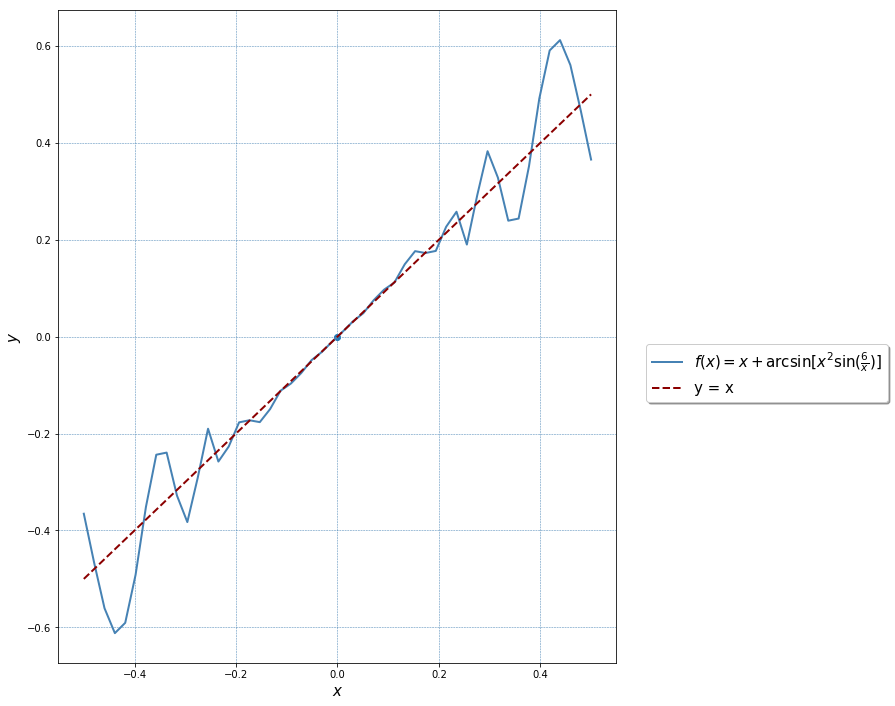

```python
x = numpy.linspace(-0.5, 0.5)
f =  lambda x: x + numpy.arcsin(x ** 2 * numpy.sin( 6 / x))
flabel = r'$f(x) = x + \arcsin[ x^2 \sin(\frac{6}{x})]$'
y = numpy.piecewise(x, [x < 0, x > 0, x == 0], [f, f, 0])

plt.figure(figsize=(10,12)) ; plt.grid(c='steelblue',ls='--',lw=0.5)
plt.plot(x, y, c='steelblue', lw=2, label=flabel)
plt.plot(x, x, c='darkred',ls='--',lw=2, label='y = x')
plt.scatter(0,0)

plt.xlabel(r'$x$', fontsize=15); plt.ylabel(r'$y$', fontsize=15)
plt.legend(fontsize=15, shadow=True, bbox_to_anchor=(1.5,0.5));
```

## Типовой расчет №2

Составить уравнение нормали и уравнение касательной к данной кривой в точке с абсциссой $x_0$:

$\large{\displaystyle{y = 2 x^2 + 3; \ x_0 = -1}}$

## Решение

Уравнение касательной в точке $x_0$:

$\large{\displaystyle{y - f(x_0) = f'(x_0)(x - x_0)}}$.

Уравнение нормали в точке $x_0$:

$\large{\displaystyle{y - f(x_0) = -\frac{1}{f'(x_0)}(x - x_0)}}$.

В данном случае:

$\large{\displaystyle{f(x_0) = f(-1) = 2 * (-1)^2 + 3 = 5}}$;

$\large{\displaystyle{f'(x) = 4x \implies f'(x_0) = f'(-1) = 4 * (-1) = -4}}$

Уравнение касательной в точке $x_0$:

$\large{\displaystyle{y - 5 = (-4)(x - (-1)) \iff y = -4x + 1}}$.

Уравнение нормали в точке $x_0$:

$\large{\displaystyle{y - 5 = -\frac{1}{-4}(x - (-1)) \iff y = 0.25x + 5.25}}$.

## Ответ

Уравнение касательной в точке $x_0 = -1: y = -4x + 1$.

Уравнение нормали в точке $x_0 = -1: y = 0.25x + 5.25$.

```python
x = Symbol('x')
f = 2 * x ** 2 + 3
```

```python
f.evalf(subs={x:-1}), diff(f, x).evalf(subs={x:-1})
```

$$\left ( 5.0, \quad -4.0\right )$$

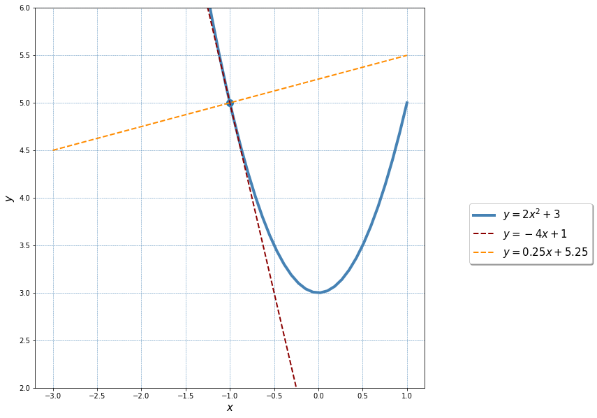

```python
x = numpy.linspace(-3, 1)
f =  lambda x: 2 * x ** 2 + 3

plt.figure(figsize=(10,10)) ; plt.grid(c='steelblue',ls='--',lw=0.5)
plt.plot(x, f(x), c='steelblue', lw=4, label=r'$y = 2x^2 + 3$')
plt.plot(x, -4 * x + 1, c='darkred',ls='--',lw=2, label=r'$y = -4x + 1$')
plt.plot(x, 0.25 * x + 5.25, c='darkorange',ls='--',lw=2, label=r'$y = 0.25x + 5.25$')
plt.scatter(-1,5, s=100)

plt.xlabel(r'$x$', fontsize=15); plt.ylabel(r'$y$', fontsize=15); plt.ylim(2,6)
plt.legend(fontsize=15, shadow=True, bbox_to_anchor=(1.1,0.5));
```

## Типовой расчет №3

Вычислить приближенно с помощью дифференциала

$\large{\displaystyle{y = x^7; \ x = 2.002 }}$

## Решение

Функция $f(x) = x^7$ дифференцируема и непрерывна на всей числовой прямой,

в том числев точке $x_0 = 2$.

Ее приращение в этой точке равно:

$f(x_0 + \Delta x) - f(x_0) = f'(x_0) \Delta x + \overline{o}(\Delta x), \ \Delta x \to 0, \overline{o}(\Delta x) \to 0$, причем

$\overline{o}(\Delta x)$ - бесконечно малая функция более высокого порядка, чем $f'(x_0) \Delta x$ при $\Delta x \to 0$.

Значит, справедливо приближенное равенство:

$f(x_0 + \Delta x) - f(x_0) \approx f'(x_0) \Delta x = df(x_0)$, где

$df(x_0)$ - дифференциал функции в точке $x_0$.

Т.е. $f(x_0 + \Delta x) \approx f(x_0) + df(x_0)$.

$x_0 = 2; \ x = 2.002 \implies \Delta x = x - x_0 = 2.002 - 2 = 0.002$

$f(x_0) = f(2) = 2^7 = 128$

$f'(x) = 7 * x^6 \implies f'(x_0) = f'(2) = 7 * 64 = 448$

$f(x_0 + \Delta x) = f(2.002) \approx f(x_0) + df(x_0) = 128 + 448 * 0.002 = 128.896$

## Ответ

$\large{\displaystyle{ (2.002)^7 \approx 128.896 }}$.

```python
x = Symbol('x')
f = x ** 7
```

```python
f.evalf(subs={x:2}), diff(f, x).evalf(subs={x:2})
```

$$\left ( 128.0, \quad 448.0\right )$$

```python
7 * 2 ** 6 * 0.002 + 128, 2.002 ** 7
```

$$\left ( 128.896, \quad 128.89869248448258\right )$$

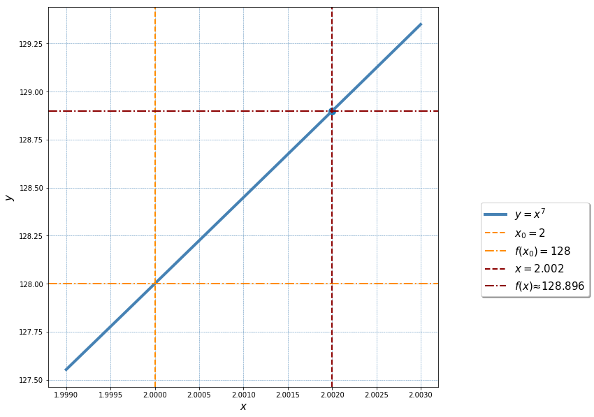

```python
x = numpy.linspace(1.999, 2.003)
f =  lambda x: x ** 7

plt.figure(figsize=(10,10)) ; plt.grid(c='steelblue',ls='--',lw=0.5)
plt.plot(x, f(x), c='steelblue', lw=4, label=r'$y = x^7$')
plt.axvline(2,c='darkorange',ls='--',lw=2, label=r'$x_0 = 2$')
plt.axhline(f(2),c='darkorange',ls='-.',lw=2, label=r'$f(x_0) = 128$')
plt.axvline(2.002,c='darkred',ls='--',lw=2, label=r'$x = 2.002$')
plt.axhline(f(2.002),c='darkred',ls='-.',lw=2, label=r'$f(x) ≈ 128.896$')

plt.scatter(2.002,f(2.002), s=100)
plt.xlabel(r'$x$', fontsize=15); plt.ylabel(r'$y$', fontsize=15);
plt.legend(fontsize=15, shadow=True, bbox_to_anchor=(1.4,0.5));
```

## Типовой расчет №4

Найти производную

$\large{\displaystyle{y = \frac{x^6 + x^3 - 2}{\sqrt{1 - x^3}} }}$

## Решение

Применим правило дифференцирования частного функций:

$\large{\displaystyle{y' = \Bigg(\frac{x^6 + x^3 - 2}{\sqrt{1 - x^3}}\Bigg)' = \frac{(x^6 + x^3 - 2)' \sqrt{1 - x^3} - (x^6 + x^3 - 2)(\sqrt{1 - x^3})'}{(\sqrt{1 - x^3})^2} =}}$

$\large{\displaystyle{ = \frac{(6x^5 + 3x^2)\sqrt{1 - x^3} - (x^6 + x^3 - 2) (-0.5) (\sqrt{1 - x^3})^{-1} 3 x^2 }{1 - x^3} = }}$

$\large{\displaystyle{ = \frac{(6x^5 + 3x^2)(1 - x^3) - (x^6 + x^3 - 2) (-0.5) 3 x^2 }{(1 - x^3)\sqrt{1 - x^3}} = }}$

$\large{\displaystyle{ = \frac{-6x^8 + 3x^5 + 3x^2 + 1.5x^2 (x^6 + x^3 - 2)}{(1 - x^3)\sqrt{1 - x^3}} = \frac{-4.5 x^8 + 4.5 x^5}{(1 - x^3)\sqrt{1 - x^3}} = }}$

$\large{\displaystyle{ = \frac{4.5 x^5 (1 - x^3)}{(1 - x^3)\sqrt{1 - x^3}} = \frac{4.5 x^5}{\sqrt{1 - x^3}} }}$

## Ответ

$\large{\displaystyle{ y' = \frac{4.5 x^5}{\sqrt{1 - x^3}} }}$.

```python
x = Symbol('x')
y = (x ** 6 + x ** 3 - 2) / (1 - x ** 3) ** 0.5
```

```python
diff(y, x)
```

$$\frac{1.5 x^{2} \left(x^{6} + x^{3} - 2\right)}{\left(- x^{3} + 1\right)^{1.5}} + \frac{6 x^{5} + 3 x^{2}}{\left(- x^{3} + 1\right)^{0.5}}$$

```python
expand(diff(y, x))
```

$$\frac{1.5 x^{8}}{\left(- x^{3} + 1\right)^{1.5}} + \frac{1.5 x^{5}}{\left(- x^{3} + 1\right)^{1.5}} + \frac{6 x^{5}}{\left(- x^{3} + 1\right)^{0.5}} - \frac{3.0 x^{2}}{\left(- x^{3} + 1\right)^{1.5}} + \frac{3 x^{2}}{\left(- x^{3} + 1\right)^{0.5}}$$

```python
simplify(diff(y, x))
```

$$\frac{x^{2}}{\left(- x^{3} + 1\right)^{2.0}} \left(\left(- x^{3} + 1\right)^{0.5} \left(1.5 x^{6} + 1.5 x^{3} - 3.0\right) + \left(- x^{3} + 1\right)^{1.5} \left(6 x^{3} + 3\right)\right)$$

```python
g = 4.5 * x ** 5 / (1 - x ** 3) ** 0.5
g
```

$$\frac{4.5 x^{5}}{\left(- x^{3} + 1\right)^{0.5}}$$

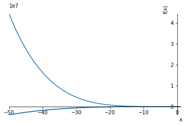

```python
plot(y, diff(y,x), g, (x,-50,1));
```

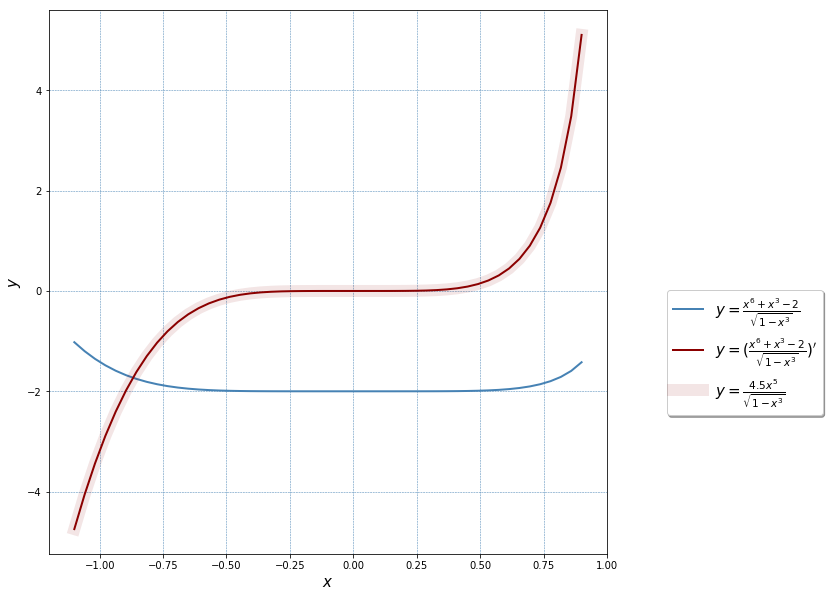

```python
x = numpy.linspace(-1.1, 0.9)
f =  lambda x: (x ** 6 + x ** 3 - 2) / (1 - x ** 3) ** 0.5
df = lambda x: (6 * x ** 5 + 3 * x ** 2) / (1 - x ** 3) ** 0.5 + 1.5 * x ** 2 *  (x ** 6 + x ** 3 - 2) / (1 - x ** 3) ** 1.5
g = lambda x: 4.5 * x ** 5 / (1 - x ** 3) ** 0.5

plt.figure(figsize=(10,10)) ; plt.grid(c='steelblue',ls='--',lw=0.5)
plt.plot(x, f(x), c='steelblue', lw=2, label=r'$y = \frac{x^6 + x^3 - 2}{\sqrt{1 - x^3}}$')
plt.plot(x, df(x), c='darkred', lw=2, label=r'$y = (\frac{x^6 + x^3 - 2}{\sqrt{1 - x^3}})^{\prime}$')
plt.plot(x, g(x), c='darkred', lw=12, alpha=0.1, label=r'$y = \frac{4.5x^5}{\sqrt{1 - x^3}}$')

plt.xlabel(r'$x$', fontsize=15); plt.ylabel(r'$y$', fontsize=15);
plt.legend(fontsize=15, shadow=True, bbox_to_anchor=(1.4,0.5));
```

## Типовой расчет №5

Найти производную

$\large{\displaystyle{y = \frac{1}{2}\sqrt{\frac{1}{x^2} - 1} - \frac{\arccos x}{2x^2} }}$

## Решение

Выполним тождественные преобразования:

$\large{\displaystyle{y = \frac{1}{2}\sqrt{\frac{1}{x^2} - 1} - \frac{\arccos x}{2x^2} = \frac{\sqrt{1 - x^2}}{2x} - \frac{\arccos x}{2x^2} = \frac{x \sqrt{1 - x^2} - \arccos x}{2x^2} }}$

Применим правило дифференцирования частного функций:

$\large{\displaystyle{y' = \Bigg(\frac{x\sqrt{1 - x^2} - \arccos x}{2x^2}\Bigg)' = }}$

$\large{\displaystyle{= \frac{(x\sqrt{1 - x^2} - \arccos x)' * 2 x^2 - (x\sqrt{1 - x^2} - \arccos x) * (2 x^2)'}{4x^4} (*) }}$

Применим правило дифференцирования произведения:

$\large{\displaystyle{(x\sqrt{1 - x^2})' = x' * \sqrt{1 - x^2} + x * (\sqrt{1 - x^2})' = }}$

$\large{\displaystyle{= 1 * \sqrt{1 - x^2} + x * 0.5 * (\sqrt{1 - x^2})^{-1} * (-2x) = }}$

$\large{\displaystyle{= \frac{(\sqrt{1 - x^2})^2 - x^2} {\sqrt{1 - x^2}} = \frac{1 - 2x^2} {\sqrt{1 - x^2}} }}$

$\large{\displaystyle{(\arccos x)' = -\frac{1}{\sqrt{1 - x^2}} }}$

$\large{\displaystyle{(x\sqrt{1 - x^2} - \arccos x)' = \frac{1 - 2x^2} {\sqrt{1 - x^2}} + \frac{1}{\sqrt{1 - x^2}} = \frac{2 (1 - x^2)}{\sqrt{1 - x^2}} = 2\sqrt{1 - x^2} }} $

Подставим в $(*)$:

$\large{\displaystyle{y' = \frac{2 \sqrt{1 - x^2} * 2 x^2 - (x \sqrt{1 - x^2} - \arccos x) * 4 x}{4 x^4} = }}$

$\large{\displaystyle{y' = \frac{4 x^2 \sqrt{1 - x^2} - 4 x^2 \sqrt{1 - x^2} + 4 x \arccos x}{4 x^4} = \frac{\arccos x}{x^3} }}$

## Ответ

$\large{\displaystyle{y' = \frac{\arccos x}{x^3} }}$

```python
x = Symbol('x')
y = 0.5 * (1 / x ** 2 - 1) ** 0.5  - acos(x) / (2 * x ** 2)
y
```

$$0.5 \left(-1 + \frac{1}{x^{2}}\right)^{0.5} - \frac{\operatorname{acos}{\left (x \right )}}{2 x^{2}}$$

```python
diff(y,x)
```

$$\frac{1}{2 x^{2} \sqrt{- x^{2} + 1}} - \frac{0.5}{x^{3} \left(-1 + \frac{1}{x^{2}}\right)^{0.5}} + \frac{1}{x^{3}} \operatorname{acos}{\left (x \right )}$$

```python
g = acos(x) / x ** 3
g
```

$$\frac{1}{x^{3}} \operatorname{acos}{\left (x \right )}$$

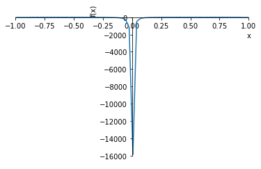

```python
plot(y, (x,-1,1));
```

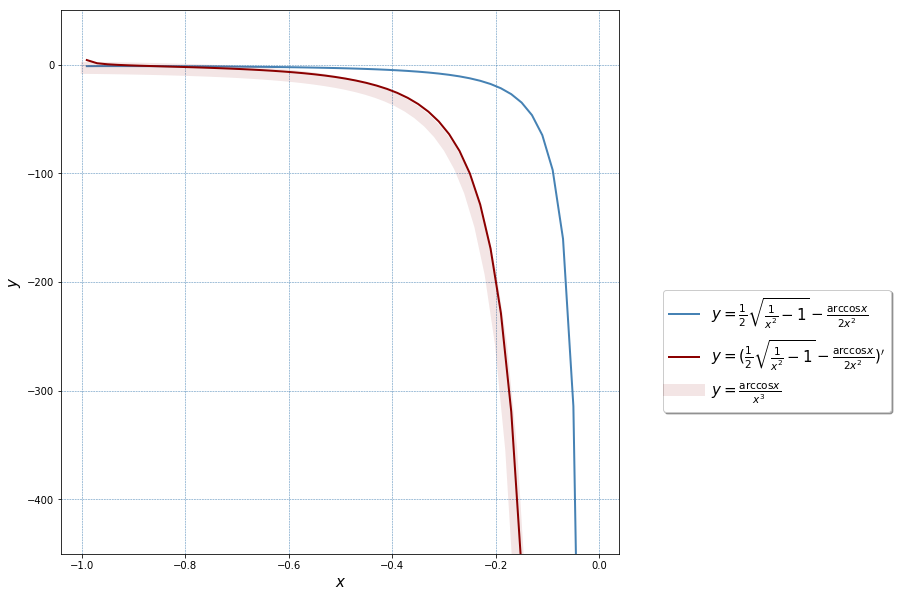

```python
x = numpy.linspace(-0.99, -0.01)
f =  lambda x: 0.5 * (1 / x ** 2 - 1) ** 0.5  - numpy.arccos(x) / (2 * x ** 2)
df = lambda x: 1/ (2 * x ** 2 * (1 - x ** 2) ** 0.5) - 0.5 / (x ** 3 *  (1 / x ** 2 - 1) ** 0.5) + numpy.arccos(x) / x ** 3
g = lambda x: numpy.arccos(x) / x ** 3

plt.figure(figsize=(10,10)) ; plt.grid(c='steelblue',ls='--',lw=0.5)
plt.plot(x, f(x), c='steelblue', lw=2, label=r'$y = \frac{1}{2}\sqrt{\frac{1}{x^2} - 1} - \frac{\arccos x}{2x^2}$')
plt.plot(x, df(x), c='darkred', lw=2, label=r'$y = (\frac{1}{2}\sqrt{\frac{1}{x^2} - 1} - \frac{\arccos x}{2x^2})^{\prime}$')
plt.plot(x, g(x), c='darkred', lw=12, alpha=0.1, label=r'$y = \frac{\arccos x}{x^3}$')

plt.xlabel(r'$x$', fontsize=15); plt.ylabel(r'$y$', fontsize=15)
plt.ylim(-450,50)
plt.legend(fontsize=15, shadow=True, bbox_to_anchor=(1.5,0.5));
```

## Типовой расчет №6

Найти производную

$\large{\displaystyle{y = \frac{1 - 8 ch^2x}{4 ch^4 x} }}$

## Решение

Применим правило дифференцирования частного функций и другие арифметические свойства производных.

$\large{\displaystyle{y ' = \Bigg( \frac{1 - 8 ch^2x}{4 ch^4 x} \Bigg) ' = \frac{(1 - 8 ch^2x) ' 4 ch^4 x - (1 - 8 ch^2x)(4 ch^4 x)' }{16 ch^8 x} = }}$

$\large{\displaystyle{ = \frac{- 16 ch \ x \ sh \ x \ 4 ch^4 x - (1 - 8 ch^2x) \ 16 ch^3 x \ sh \ x}{16 ch^8 x} = }}$

$\large{\displaystyle{ = \frac{(8 ch^2x - 1) \ sh \ x - 4 sh \ x \ ch^2 x}{ch^5 x} = \frac{sh \ x (4 ch^2 x - 1)}{ch^5 x} (*) }}$

Упростим числитель дроби, используя формулы гиперболических синуса и косинуса:

$\large{\displaystyle{ sh \ x (4 ch^2 x - 1) = \frac{e^x - e^{-x}}{2} (4 (e^x - e^{-x})^2 / 4 - 1) = }}$

$\large{\displaystyle{= \frac{(e^x - e^{-x})((e^x - e^{-x})^2 - 1)}{2} = \frac{(e^x - e^{-x})((e^x)^2 + e^x e^{-x} + (e^{-x})^2) }{2} = }}$

$\large{\displaystyle{= \frac{(e^x)^3 - ( e^{-x})^3 }{2} = \frac{e^{3x} - e^{-3x} }{2} = sh \ 3x}}$

Подставим в $(*)$:

$\large{\displaystyle{y ' = \frac{sh \ 3x}{ch^5 x} }}$

## Ответ

$\large{\displaystyle{y ' = \frac{sh \ 3x}{ch^5 x} }}$

```python
x = Symbol('x')
f = 1 - 8 * cosh(x) ** 2
g = 4 * cosh(x) ** 4
```

```python
diff(f, x), diff(g, x)
```

$$\left ( - 16 \sinh{\left (x \right )} \cosh{\left (x \right )}, \quad 16 \sinh{\left (x \right )} \cosh^{3}{\left (x \right )}\right )$$

```python
y = (1 - 8 * cosh(x) ** 2) / (4 * cosh(x) ** 4)
y
```

$$\frac{- 8 \cosh^{2}{\left (x \right )} + 1}{4 \cosh^{4}{\left (x \right )}}$$

```python
diff(y, x)
```

$$- \frac{\sinh{\left (x \right )}}{\cosh^{5}{\left (x \right )}} \left(- 8 \cosh^{2}{\left (x \right )} + 1\right) - \frac{4 \sinh{\left (x \right )}}{\cosh^{3}{\left (x \right )}}$$

```python
h = sinh(3 * x) / cosh(x) ** 5
h
```

$$\frac{\sinh{\left (3 x \right )}}{\cosh^{5}{\left (x \right )}}$$

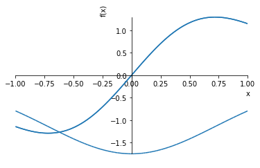

```python
plot(y, diff(y,x), h, (x,-1,1));
```

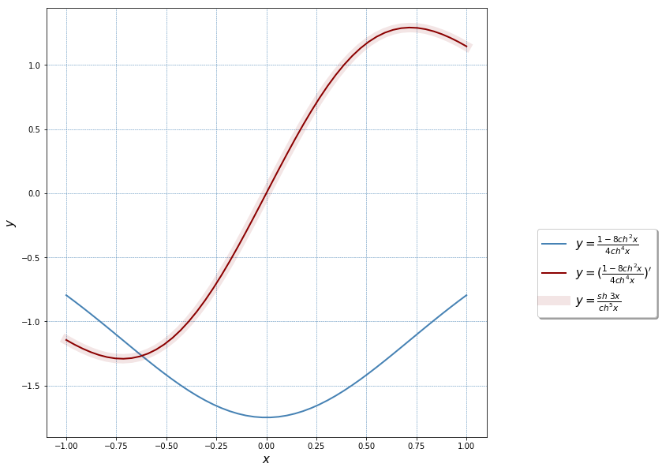

```python
x = numpy.linspace(-1, 1)
f =  lambda x: (1 - 8 * numpy.cosh(x) ** 2) / (4 * numpy.cosh(x) ** 4)
df = lambda x: - numpy.sinh(x) * (1 - 8 * numpy.cosh(x) ** 2) / numpy.cosh(x) ** 5 - 4 * numpy.sinh(x) / numpy.cosh(x) ** 3
g = lambda x: numpy.sinh(3 * x) / numpy.cosh(x) ** 5

plt.figure(figsize=(10,10)) ; plt.grid(c='steelblue',ls='--',lw=0.5)
plt.plot(x, f(x), c='steelblue', lw=2, label=r'$y = \frac{1 - 8 ch^2x}{4 ch^4 x}$')
plt.plot(x, df(x), c='darkred', lw=2, label=r'$y = (\frac{1 - 8 ch^2x}{4 ch^4 x})^{\prime}$')
plt.plot(x, g(x), c='darkred', lw=12, alpha=0.1, label=r'$y = \frac{sh \ 3x}{ch^5 x}$')

plt.xlabel(r'$x$', fontsize=15); plt.ylabel(r'$y$', fontsize=15)
plt.legend(fontsize=15, shadow=True, bbox_to_anchor=(1.4,0.5));
```

## Типовой расчет №7

Найти производную

$\large{\displaystyle{y = x^{e^ {ctg \ x}} }}$

## Решение

Применим правило дифференцирования сложной функции.

Воспользуемся известным способом для показательно-степенных функций:

- прологарифмируем исходную функцию,
- найдем производную от полученного выражения

$\large{\displaystyle{(\ln y)' = \frac{y '}{ y} \iff y ' = y \ (\ln y)' (*)}}$

$\large{\displaystyle{(\ln y) ' = [ \ln(x^{e^{ctg \ x}}) ] ' = (e^{ctg \ x} \ln x) ' = }}$

$\large{\displaystyle{= (e^{ctg \ x}) ' \ln x + e^{ctg \ x} (\ln x) ' = e^{ctg \ x} \ (ctg \ x) ' \ln x + \frac {e^{ctg \ x}}{x} = }}$

$\large{\displaystyle{= e^{ctg \ x} \bigg( \frac {1}{x} - \frac{\ln x}{\sin^2 x} \bigg) }}$

Подставим в $(*)$:

$\large{\displaystyle{ y ' = x^{e^ {ctg \ x}} e^{ctg \ x} \bigg( \frac {1}{x} - \frac{\ln x}{\sin^2 x} \bigg) }}$

## Ответ

$\large{\displaystyle{ y ' = x^{e^ {ctg \ x}} e^{ctg \ x} \bigg( \frac {1}{x} - \frac{\ln x}{\sin^2 x} \bigg) }}$

```python
x = Symbol('x')
y = x ** (E ** (cot(x)))
y
```

$$x^{e^{\cot{\left (x \right )}}}$$

```python
diff(y, x)
```

$$x^{e^{\cot{\left (x \right )}}} \left(\left(- \cot^{2}{\left (x \right )} - 1\right) e^{\cot{\left (x \right )}} \log{\left (x \right )} + \frac{1}{x} e^{\cot{\left (x \right )}}\right)$$

```python
g = x ** (E ** (cot(x))) *  E ** (cot(x)) * (1 / x - log(x) / sin(x) ** 2)
g
```

$$x^{e^{\cot{\left (x \right )}}} \left(- \frac{\log{\left (x \right )}}{\sin^{2}{\left (x \right )}} + \frac{1}{x}\right) e^{\cot{\left (x \right )}}$$

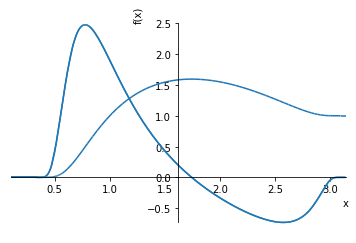

```python
plot(y, diff(y,x), g, (x, 0.1, pi));
```

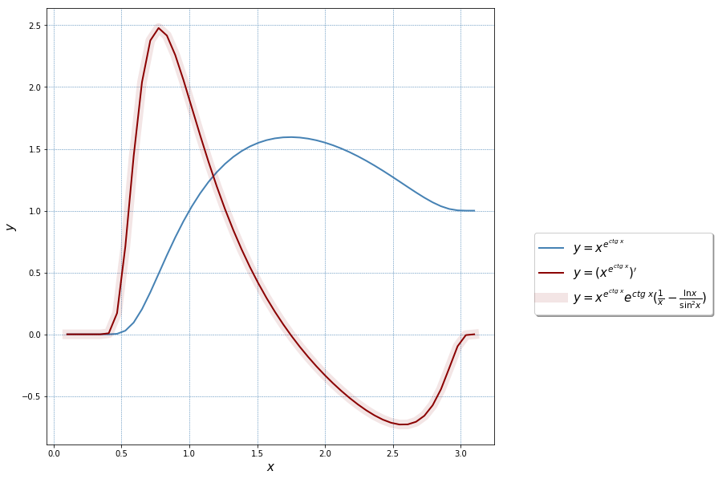

```python
x = numpy.linspace(0.1, 3.1)
f =  lambda x:  x ** ( numpy.exp( 1 / numpy.tan(x) ) )
df = lambda x: x ** ( numpy.exp( 1 / numpy.tan(x) ) ) * \
((-1 /  numpy.tan(x) ** 2 - 1) * numpy.exp( 1 / numpy.tan(x) ) * \
numpy.log(x) + numpy.exp( 1 / numpy.tan(x) ) / x)

g = lambda x:  x ** ( numpy.exp( 1 / numpy.tan(x) ) ) *  \
numpy.exp (1 / numpy.tan(x)) * (1 / x - numpy.log(x) / numpy.sin(x) ** 2)

plt.figure(figsize=(10,10)) ; plt.grid(c='steelblue',ls='--',lw=0.5)
plt.plot(x, f(x), c='steelblue', lw=2, label=r'$y = x^{e^ {ctg \ x}}$')
plt.plot(x, df(x), c='darkred', lw=2, label=r'$y = (x^{e^ {ctg \ x}})^{\prime}$')
plt.plot(x, g(x), c='darkred', lw=12, alpha=0.1, label=r'$y = x^{e^ {ctg \ x}} e^{ctg \ x} ( \frac {1}{x} - \frac{\ln x}{\sin^2 x} )$')

plt.xlabel(r'$x$', fontsize=15); plt.ylabel(r'$y$', fontsize=15)
plt.legend(fontsize=15, shadow=True, bbox_to_anchor=(1.5,0.5));
```